# Prosper Loan Data Analysis by Oliver Phipps

> In this analysis I am going to look at the Prosper Loan Data - I have imported the relevant libraries and I will first take a look at the data.

```
## 'data.frame':    113937 obs. of  81 variables:
##  $ ListingKey                         : Factor w/ 113066 levels "00003546482094282EF90E5",..: 7180 7193 6647 6669 6686 6689 6699 6706 6687 6687 ...
##  $ ListingNumber                      : int  193129 1209647 81716 658116 909464 1074836 750899 768193 1023355 1023355 ...
##  $ ListingCreationDate                : Factor w/ 113064 levels "2005-11-09 20:44:28.847000000",..: 14184 111894 6429 64760 85967 100310 72556 74019 97834 97834 ...
##  $ CreditGrade                        : Factor w/ 9 levels "","A","AA","B",..: 5 1 8 1 1 1 1 1 1 1 ...
##  $ Term                               : int  36 36 36 36 36 60 36 36 36 36 ...
##  $ LoanStatus                         : Factor w/ 12 levels "Cancelled","Chargedoff",..: 3 4 3 4 4 4 4 4 4 4 ...
##  $ ClosedDate                         : Factor w/ 2803 levels "","2005-11-25 00:00:00",..: 1138 1 1263 1 1 1 1 1 1 1 ...
##  $ BorrowerAPR                        : num  0.165 0.12 0.283 0.125 0.246 ...
##  $ BorrowerRate                       : num  0.158 0.092 0.275 0.0974 0.2085 ...
##  $ LenderYield                        : num  0.138 0.082 0.24 0.0874 0.1985 ...
##  $ EstimatedEffectiveYield            : num  NA 0.0796 NA 0.0849 0.1832 ...
##  $ EstimatedLoss                      : num  NA 0.0249 NA 0.0249 0.0925 ...
##  $ EstimatedReturn                    : num  NA 0.0547 NA 0.06 0.0907 ...
##  $ ProsperRating..numeric.            : int  NA 6 NA 6 3 5 2 4 7 7 ...
```

[output cut: 67 more lines]

```
##                    ListingKey     ListingNumber
##  17A93590655669644DB4C06:     6   Min.   :      4
##  349D3587495831350F0F648:     4   1st Qu.: 400919
##  47C1359638497431975670B:     4   Median : 600554
##  8474358854651984137201C:     4   Mean   : 627886
##  DE8535960513435199406CE:     4   3rd Qu.: 892634
##  04C13599434217079754AEE:     3   Max.   :1255725
##  (Other)                :113912
##                     ListingCreationDate  CreditGrade         Term
##  2013-10-02 17:20:16.550000000:     6          :84984   Min.   :12.00
##  2013-08-28 20:31:41.107000000:     4   C      : 5649   1st Qu.:36.00
##  2013-09-08 09:27:44.853000000:     4   D      : 5153   Median :36.00
##  2013-12-06 05:43:13.830000000:     4   B      : 4389   Mean   :40.83
##  2013-12-06 11:44:58.283000000:     4   AA     : 3509   3rd Qu.:36.00
##  2013-08-21 07:25:22.360000000:     3   HR     : 3508   Max.   :60.00
##  (Other)                      :113912   (Other): 6745
##                  LoanStatus                  ClosedDate
##  Current              :56576                      :58848
##  Completed            :38074   2014-03-04 00:00:00:  105
##  Chargedoff           :11992   2014-02-19 00:00:00:  100
##  Defaulted            : 5018   2014-02-11 00:00:00:   92
##  Past Due (1-15 days) :  806   2012-10-30 00:00:00:   81
##  Past Due (31-60 days):  363   2013-02-26 00:00:00:   78
##  (Other)              : 1108   (Other)            :54633
##   BorrowerAPR       BorrowerRate     LenderYield
##  Min.   :0.00653   Min.   :0.0000   Min.   :-0.0100
##  1st Qu.:0.15629   1st Qu.:0.1340   1st Qu.: 0.1242
##  Median :0.20976   Median :0.1840   Median : 0.1730
##  Mean   :0.21883   Mean   :0.1928   Mean   : 0.1827
##  3rd Qu.:0.28381   3rd Qu.:0.2500   3rd Qu.: 0.2400
##  Max.   :0.51229   Max.   :0.4975   Max.   : 0.4925
##  NA's   :25
##  EstimatedEffectiveYield EstimatedLoss   EstimatedReturn
##  Min.   :-0.183          Min.   :0.005   Min.   :-0.183
##  1st Qu.: 0.116          1st Qu.:0.042   1st Qu.: 0.074
##  Median : 0.162          Median :0.072   Median : 0.092
##  Mean   : 0.169          Mean   :0.080   Mean   : 0.096
##  3rd Qu.: 0.224          3rd Qu.:0.112   3rd Qu.: 0.117
##  Max.   : 0.320          Max.   :0.366   Max.   : 0.284
##  NA's   :29084           NA's   :29084   NA's   :29084
```

[output cut: 193 more lines]

```
##  Min.   :    0.00                Min.   :0.7000   Min.   : 0.00000
##  1st Qu.:    0.00                1st Qu.:1.0000   1st Qu.: 0.00000
##  Median :    0.00                Median :1.0000   Median : 0.00000
##  Mean   :   25.14                Mean   :0.9986   Mean   : 0.04803
##  3rd Qu.:    0.00                3rd Qu.:1.0000   3rd Qu.: 0.00000
##  Max.   :21117.90                Max.   :1.0125   Max.   :39.00000
##
##  InvestmentFromFriendsCount InvestmentFromFriendsAmount   Investors
##  Min.   : 0.00000           Min.   :    0.00            Min.   :   1.00
##  1st Qu.: 0.00000           1st Qu.:    0.00            1st Qu.:   2.00
##  Median : 0.00000           Median :    0.00            Median :  44.00
##  Mean   : 0.02346           Mean   :   16.55            Mean   :  80.48
##  3rd Qu.: 0.00000           3rd Qu.:    0.00            3rd Qu.: 115.00
##  Max.   :33.00000           Max.   :25000.00            Max.   :1189.00
##
```

> This data set contains 113,937 loans with multiple variables on each loan, in this analysis we will look at a number a different variables to try and understand more about the data.

# Univariate Plots Section

> The below shows a summary of some of the variables that we will explore in our analysis and helps us get a preliminary understanding.

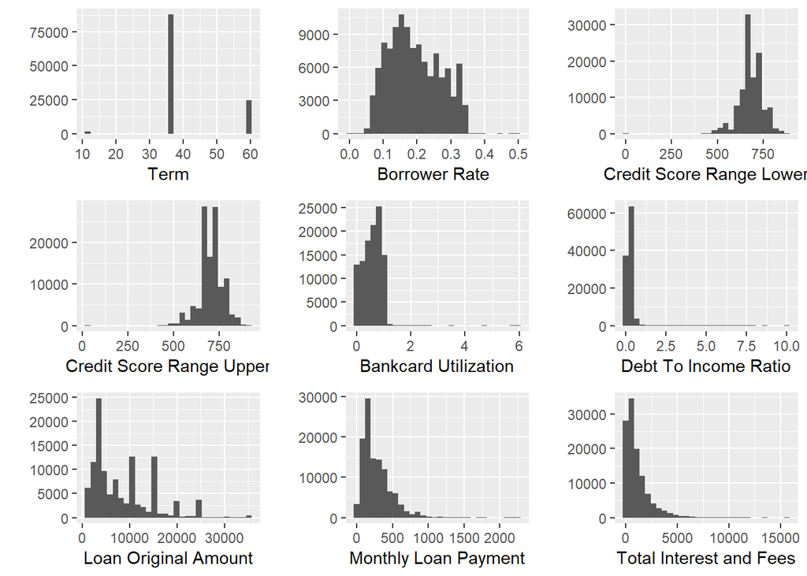

> Now lets look at two variables side by side that I we would typically consider linked, the loan amounts and loan payments

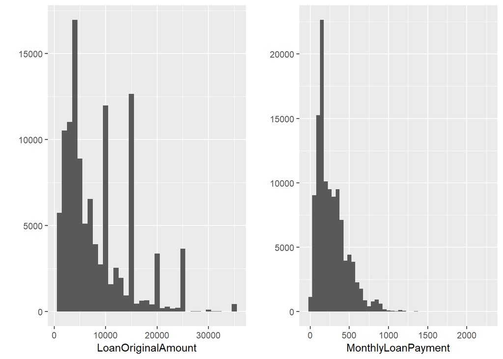

> We can see that these are both right skewed

> Now lets look at the amount of loans that the typical loanee may already have with Prosper

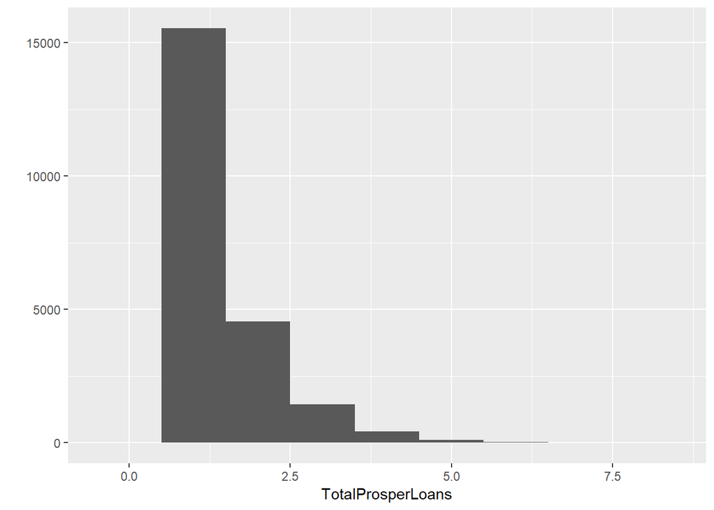

> This shows us taht a substantial amount of people already have loans with Prosper and are requesting an additional one

> Now lets look at information on Loan amounts by state, to see if these differ, we have intentionally picked out two states that are very different in terms of wealth per capita

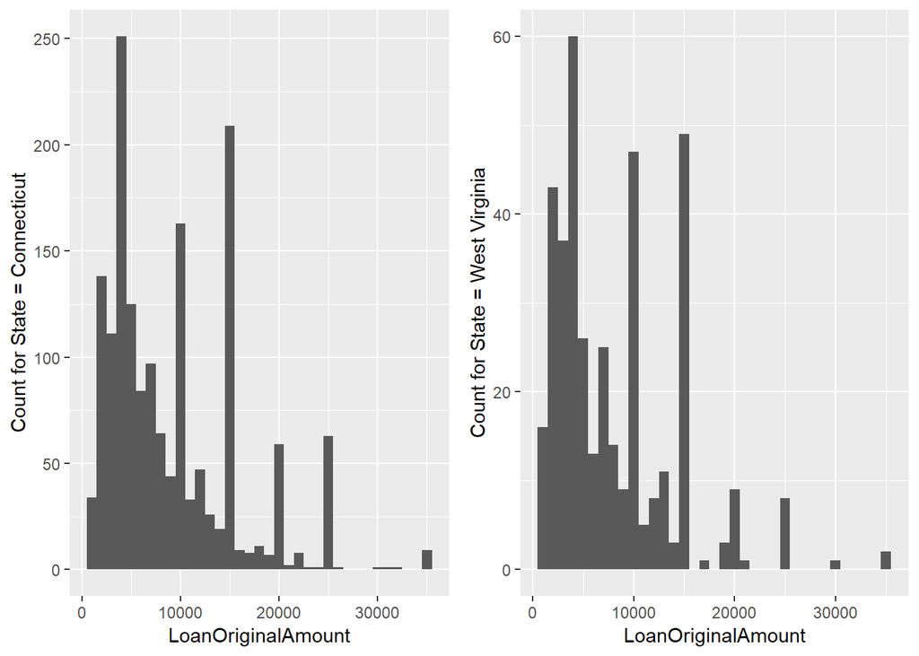

> We can see above that even though the population of these states are very different in terms of wealth, they are quite similiar if we look at the amount ehey are borrowing.

> Now lets look at some catergorical variables First we are looking at the counts of homeowners vs non homeowners to see if they prefer to offer to loanee’s with a home to use as collateral.

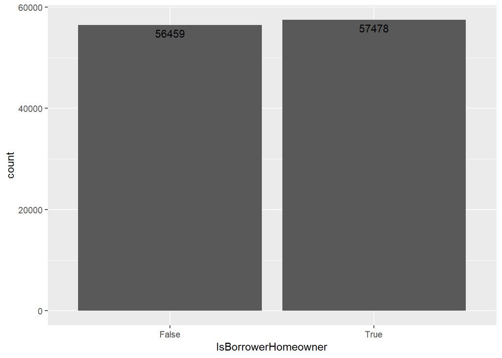

> We can see above that there is roughly the same amount of each

> Now lets look at the count of Loanee’s by there Income Range, the reason behind this is so that we can see if there is a preference for the company when offering loans or if they specialise in offering to a certain type of Loanee.

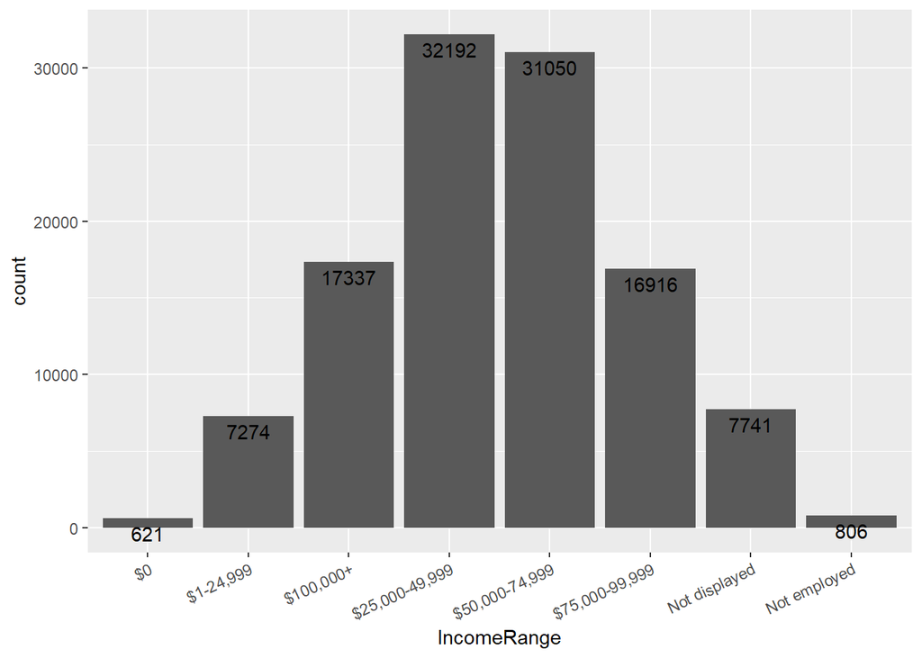

> We can see here that it is quite distributed, going forward we will sort this data so it is ordered correctly

> Now lets look at the terms of the loans so we can understand how long people typically borrow for

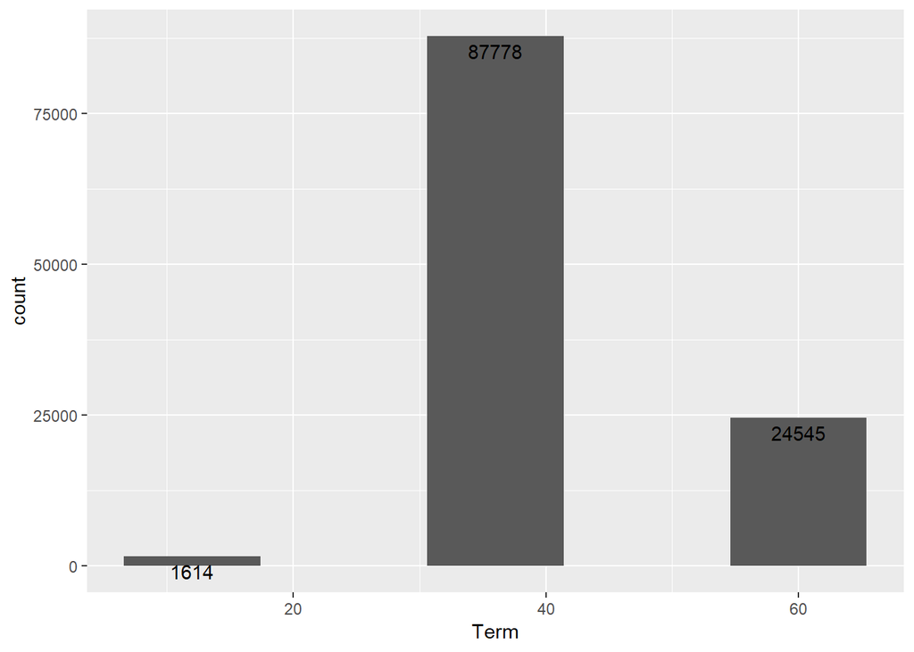

> We can see here that the normal term is 36 months, or 3 years. This shows us that the loans are quite short term and wouldnt be used for anything like buying a property (typical mortgage loan would be around 25-35 years)

> Finally lets look at Prosper Rating, the lower the number the more risky the Loanee is deemed to be

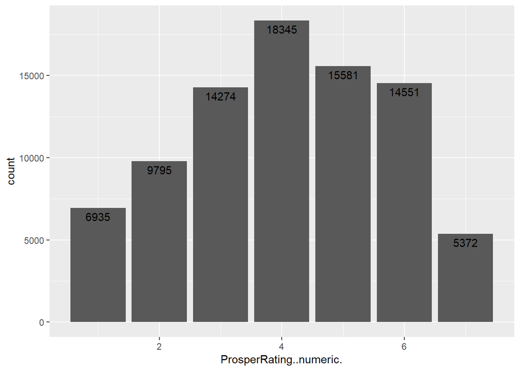

> This is normally distributed, with maybe a slightly left skew. This reason behind looking at this was to understand if the company only offers loans to certain types of people.

# Univariate Analysis

### What is the structure of your dataset?

> The data has 113,937 loans and 81 variables for each, including some that are shown above, and also some regional data which we can use to investigate more regional trends.

### What is/are the main feature(s) of interest in your dataset?

> There are many aspects of this dataset and I would not say that there is one main feature. One thing that I would like to investigate however would be regarding loans and certain income bands and how the Loan amount would diffe and therefore I would take the Loan Amount to be my main point of interest.

### Did you create any new variables from existing variables in the dataset?

> I have not yet created any new variables although throughout my analysis creating new variables, or sorting factored variables, may be neccesary to get desired results.

### Of the features you investigated, were there any unusual distributions? Did you perform any operations on the data to tidy, adjust, or change the form of the data? If so, why did you do this?

> This dataset does have some missing values for some of the variables, but the ones that I am interested in contain enough information that I feel confortable using this data without tidying. Although I am not familiar with US credit scores, I would have suspected some more variation in the scores however that may be due to a policy or some criteria of the lender.

> We can also see that on the Orignal Loan Amount, there are spikes around more standard multiples (e.g. 10k, 20k) and less loans that have a more specific amount. This may suggest that Loanee’s are perhaps rounding their requirements up or down, or that the Loaner is more likely to offer standard amounts.

> We can see in the summary chart that most are skewed, this would be expected in this dataset as we are dealing with a number of Loanees with vastly different financial situation and needs. If we look at the state specific charts we can see that they look more similiar than may be expected for two states that are very different in terms of per capita income.

# Bivariate Plots Section

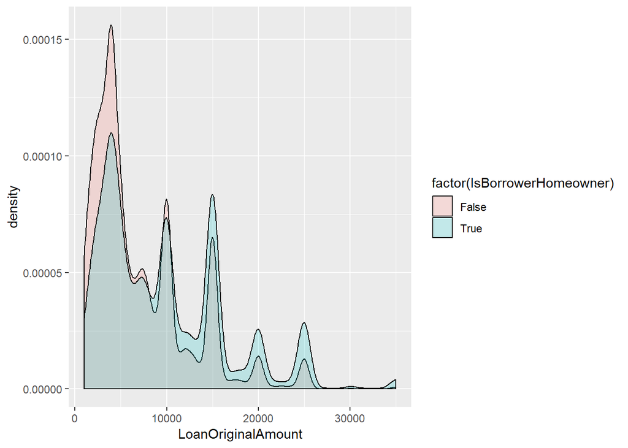

> The above gives us some insight as to the size of loans people take out if they own homes, and if they do not. We can see that non-homeowners take a out more smaller loans whilst people who own a home take out more. The inflection point here is around 10,000. The reason for us to look at this was to see if Home Owners may borrow more for maintenence to their property or if they borrow less as they could be perceived to be more wealthy.

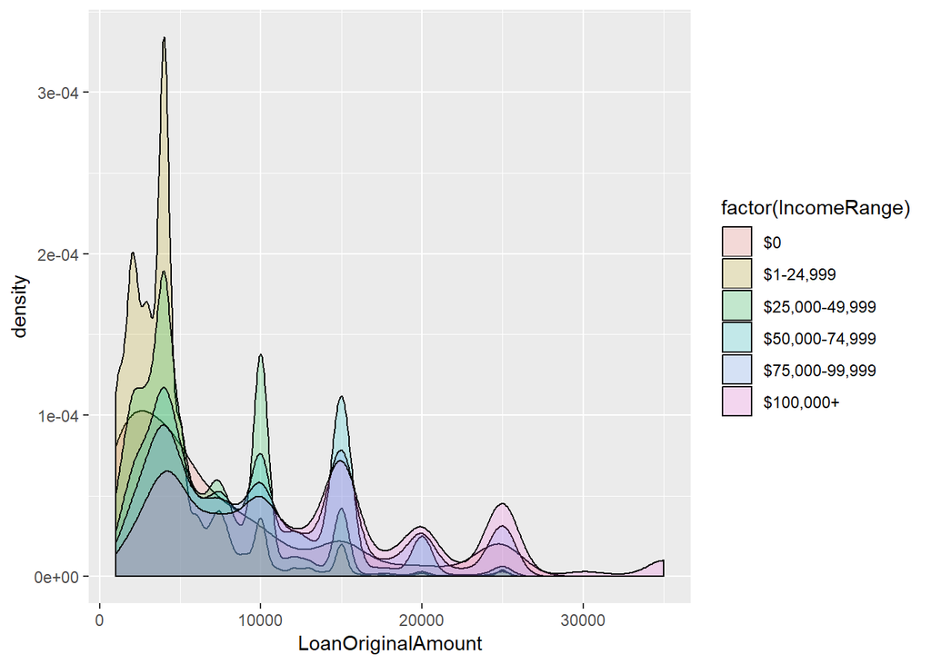

> We know that there are typically restrictions around what you can borrow depending on what you earn, but it is interesting to see this played out in the above plot. We can again see these spikes played out around round multiples to borrow (e.g. 15k shows a number of Income Ranges that are peaking.) The most interesting thing here it the prevalence of a $0 range. This may either be due to a data inputting error or around the use of collateral for loans. In this data we were using factor variables and so I used R to put these into order and also removed ‘not displayed’ and ‘not employed’. Below are some statistics drawn from the data used in the graph above. I think this is interesting and the reason behind this was too see if there was a dramatic difference in what different people with differnt income ranges may borrow.

```
## factor(df$IncomeRange): $0
##    Min. 1st Qu.  Median    Mean 3rd Qu.    Max.
##    1000    2500    5000    7411   10000   25000
## --------------------------------------------------------
## factor(df$IncomeRange): $1-24,999
##    Min. 1st Qu.  Median    Mean 3rd Qu.    Max.
##    1000    2052    4000    4274    5000   25000
## --------------------------------------------------------
## factor(df$IncomeRange): $25,000-49,999
##    Min. 1st Qu.  Median    Mean 3rd Qu.    Max.
##    1000    3000    5000    6178    9800   25000
## --------------------------------------------------------
## factor(df$IncomeRange): $50,000-74,999
##    Min. 1st Qu.  Median    Mean 3rd Qu.    Max.
##    1000    4000    7500    8675   13500   25000
## --------------------------------------------------------
## factor(df$IncomeRange): $75,000-99,999
##    Min. 1st Qu.  Median    Mean 3rd Qu.    Max.
##    1000    4000    9700   10366   15000   25000
## --------------------------------------------------------
## factor(df$IncomeRange): $100,000+
##    Min. 1st Qu.  Median    Mean 3rd Qu.    Max.
##    1000    6000   12000   13073   18500   35000
```

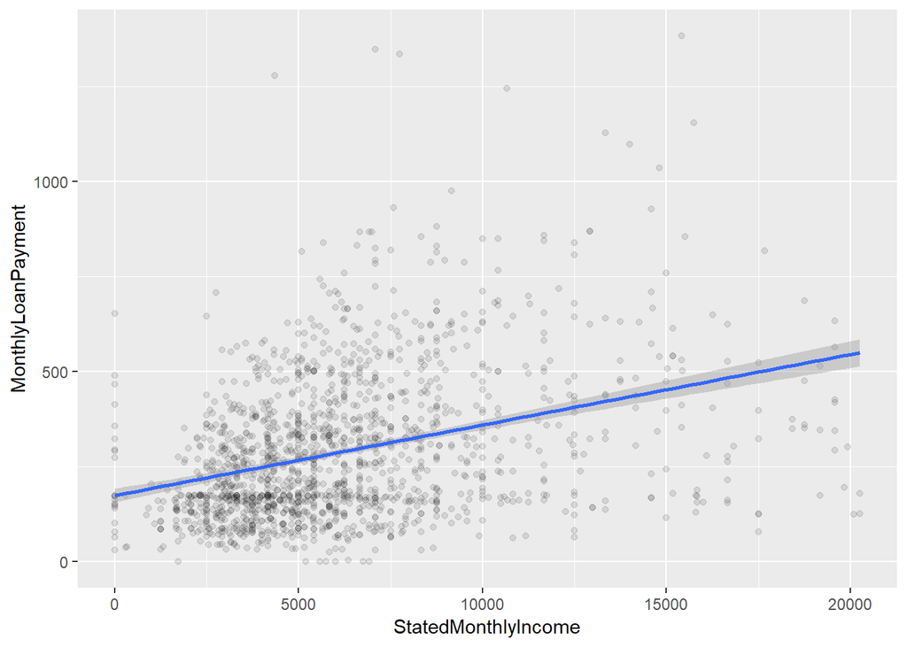

> The graph above looks at Loan Payments and Montly Income. The underlying data excludes the top 1% of earners and this chart only looks at residents of Connecticut. The reasoning behind this is due to the amount of entries, using subsets helps give us a better idea of trends. We can see that as expected, the more that is earned a month the higher than loan payments typically are. This is interesting to see as we can understand what a lower income state earnts a month compared to what they pay for loans.

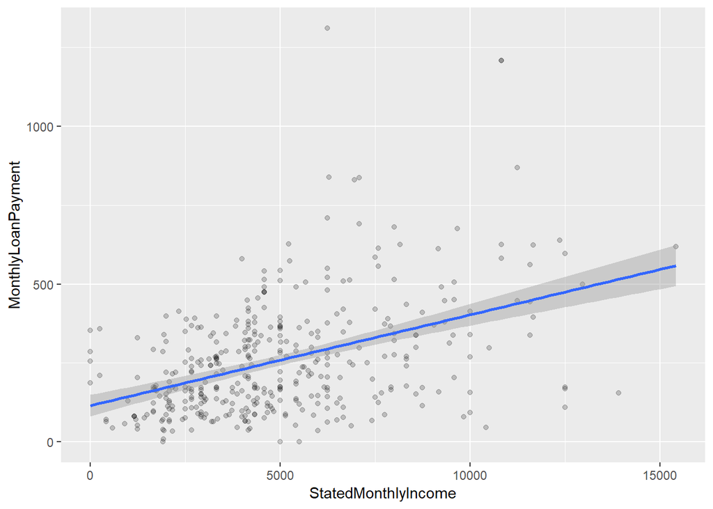

> The above chart show similiar data to the one before it, but now we are looking at residents of West Virgina. The reason behind this is that it allowed us to compare against the information for Conneticut.

# Bivariate Analysis

### Talk about some of the relationships you observed in this part of the investigation. How did the feature(s) of interest vary with other features in the dataset?

> As has been commented above, we can see that homeowners typically borrower more, as do those who are in higher Income Ranges. It would be interesting to do more future analysis around the $0 salary as we can see that this has a higher mean borrowering amount that the next two Income Range buckets. As expected we saw that the Monthly Payments are positively correlated with Monthly Income.

### Did you observe any interesting relationships between the other features (not the main feature(s) of interest)?

# Multivariate Plots Section

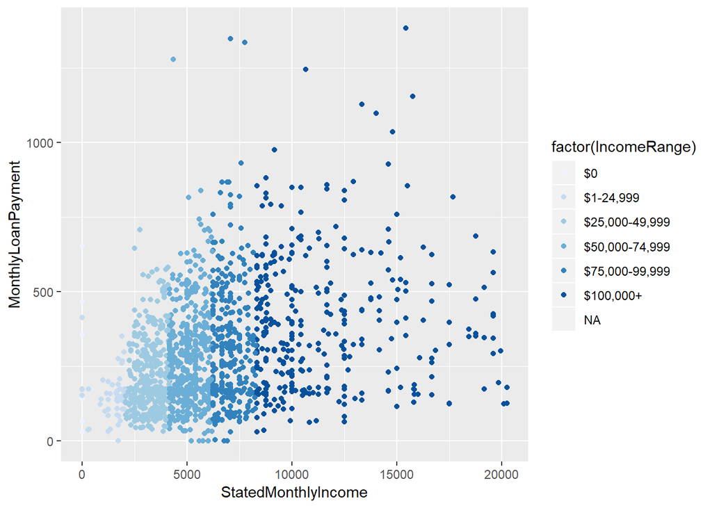

> The above shows us how monthyly income in Connecticut compares to Loans, but also breaks it out by Income Range. This is interesting as it allows to easily see (via colours) the outliers in different groups, and that was the reason for this graph.

> The below chart is looking at DC and it shows us credit scores vs income ranges. The idea behind this is to see if we are see if trends in Income Ranges relate to credit scores.

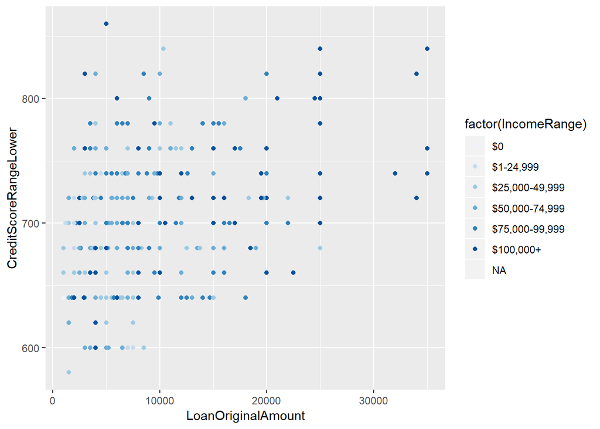

> Below is a breakdown of statistics for Monthly Loan Payment by Income Range

```
## factor(df$IncomeRange): $0
##    Min. 1st Qu.  Median    Mean 3rd Qu.    Max.
##    0.00   87.14  169.68  267.47  347.58 1130.90
## --------------------------------------------------------
## factor(df$IncomeRange): $1-24,999
##    Min. 1st Qu.  Median    Mean 3rd Qu.    Max.
##    0.00   86.38  134.28  154.67  173.71 1047.64
## --------------------------------------------------------
## factor(df$IncomeRange): $25,000-49,999
##    Min. 1st Qu.  Median    Mean 3rd Qu.    Max.
##     0.0   118.9   173.7   210.4   282.8  1382.1
## --------------------------------------------------------
## factor(df$IncomeRange): $50,000-74,999
##    Min. 1st Qu.  Median    Mean 3rd Qu.    Max.
##     0.0   155.8   253.1   280.3   383.7  1778.4
## --------------------------------------------------------
## factor(df$IncomeRange): $75,000-99,999
##    Min. 1st Qu.  Median    Mean 3rd Qu.    Max.
##     0.0   169.5   301.6   329.4   457.2  2111.8
## --------------------------------------------------------
## factor(df$IncomeRange): $100,000+
##    Min. 1st Qu.  Median    Mean 3rd Qu.    Max.
##     0.0   208.6   375.0   412.2   560.1  2251.5
```

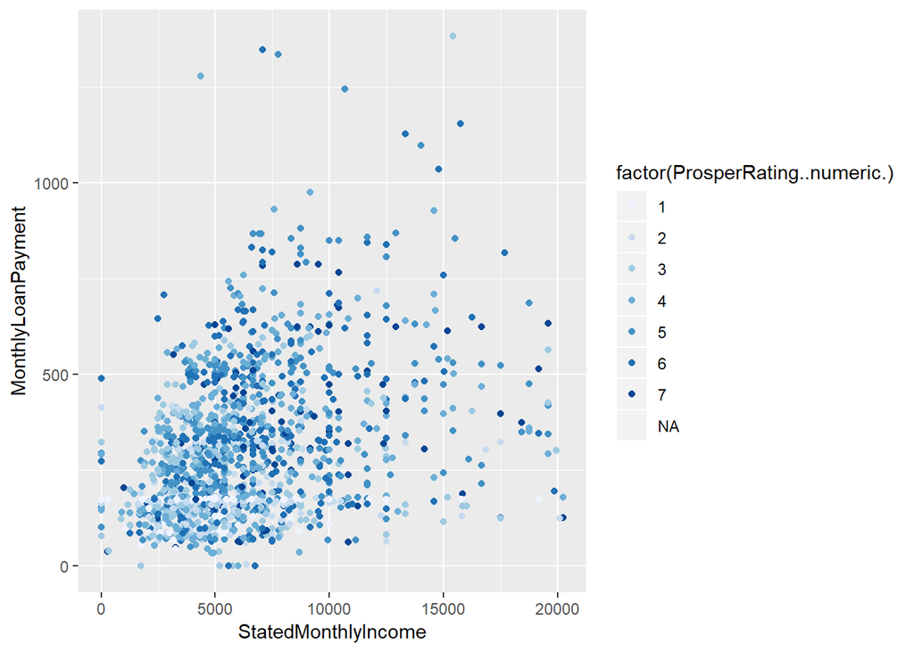

> Below is a breakdown of statistics for Monthly Loan Payment by Prosper Rating

```
## factor(df$ProsperRating..numeric.): 1
##    Min. 1st Qu.  Median    Mean 3rd Qu.    Max.
##     0.0   128.2   172.8   149.6   173.7   678.5
## --------------------------------------------------------
## factor(df$ProsperRating..numeric.): 2
##    Min. 1st Qu.  Median    Mean 3rd Qu.    Max.
##     0.0   128.7   165.2   187.1   217.7   719.0
## --------------------------------------------------------
## factor(df$ProsperRating..numeric.): 3
##    Min. 1st Qu.  Median    Mean 3rd Qu.    Max.
##     0.0   150.0   235.2   255.4   364.6  1384.6
## --------------------------------------------------------
## factor(df$ProsperRating..numeric.): 4
##    Min. 1st Qu.  Median    Mean 3rd Qu.    Max.
##     0.0   179.8   308.1   328.4   429.3  2251.5
## --------------------------------------------------------
## factor(df$ProsperRating..numeric.): 5
##    Min. 1st Qu.  Median    Mean 3rd Qu.    Max.
##     0.0   190.9   338.5   345.7   467.3  2218.5
## --------------------------------------------------------
## factor(df$ProsperRating..numeric.): 6
##    Min. 1st Qu.  Median    Mean 3rd Qu.    Max.
##     0.0   176.7   321.6   342.1   479.1  2179.2
## --------------------------------------------------------
## factor(df$ProsperRating..numeric.): 7
##    Min. 1st Qu.  Median    Mean 3rd Qu.    Max.
##     0.0   182.8   315.2   347.4   473.4  2163.6
```

> Below is a breakdown of statistics for Monthly Income by Prosper Rating

```
## factor(df$ProsperRating..numeric.): 1
##    Min. 1st Qu.  Median    Mean 3rd Qu.    Max.
##       0    2500    3867    4851    5775 1750003
## --------------------------------------------------------
## factor(df$ProsperRating..numeric.): 2
##    Min. 1st Qu.  Median    Mean 3rd Qu.    Max.
##       0    2917    4167    5021    6083  483333
## --------------------------------------------------------
## factor(df$ProsperRating..numeric.): 3
##    Min. 1st Qu.  Median    Mean 3rd Qu.    Max.
##       0    3083    4333    5184    6250  618548
## --------------------------------------------------------
## factor(df$ProsperRating..numeric.): 4
##    Min. 1st Qu.  Median    Mean 3rd Qu.    Max.
##       0    3500    5000    5827    7000  394400
## --------------------------------------------------------
## factor(df$ProsperRating..numeric.): 5
##    Min. 1st Qu.  Median    Mean 3rd Qu.    Max.
##       0    3900    5417    6438    7750  108750
## --------------------------------------------------------
## factor(df$ProsperRating..numeric.): 6
##    Min. 1st Qu.  Median    Mean 3rd Qu.    Max.
##       0    4167    5833    6744    8167   91667
## --------------------------------------------------------
## factor(df$ProsperRating..numeric.): 7
##    Min. 1st Qu.  Median    Mean 3rd Qu.    Max.
##       0    4833    6667    7656    9167  108333
```

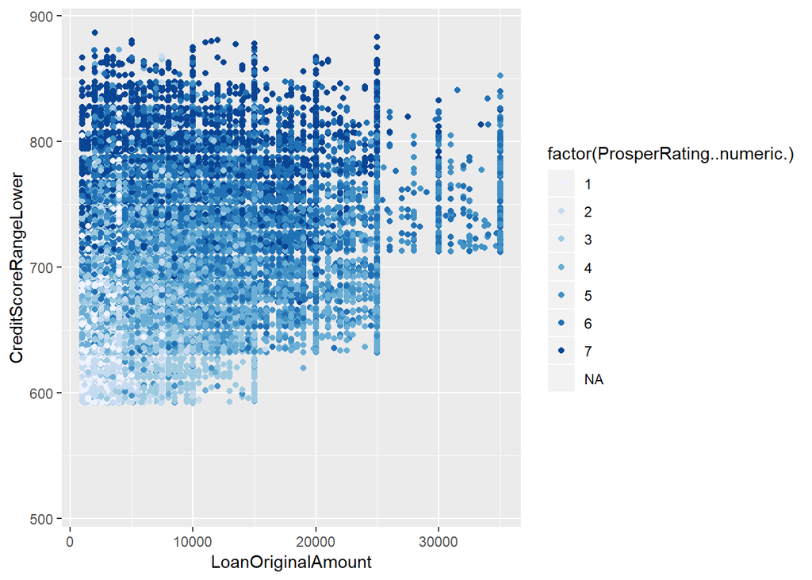

> This chart now includes all data from the dataset. We are looking at the TOtal Loan Amount, the Credit Score and the Prosper Rating. The trends that are most obvious to start with are that there are higher prospect ratings in the top left of the chart, with the lower amounts and higher credit scores. This obviously makes sense. This helps show us how close the Prosper rating is affected byt Credit Rating via colours. The reason that we have use ‘jitter’ above is that it helps add some noise to the data to help prevent overplotting, it also helps us see trends more clearly.

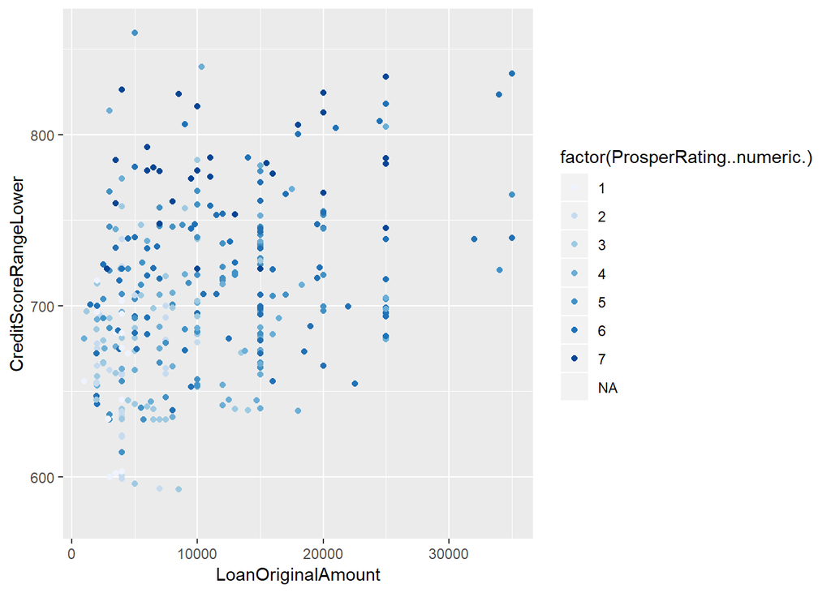

# Multivariate Analysis

### Talk about some of the relationships you observed in this part of the investigation. Were there features that strengthened each other in terms of looking at your feature(s) of interest?

# Final Plots and Summary

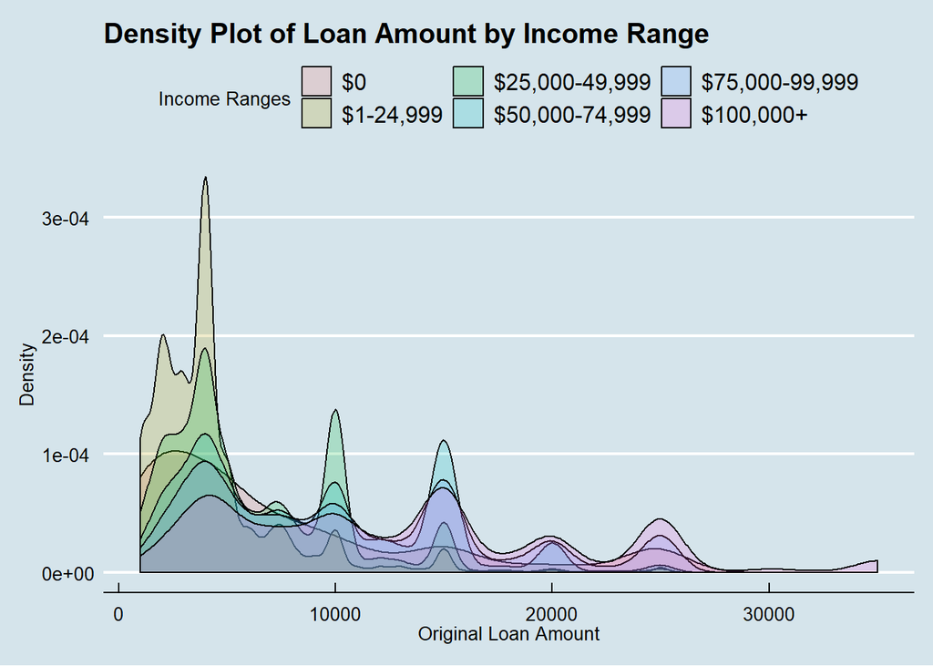

### Density Plot of Loan Amount by Income Range

> This plot shows the Loan Amount of differing Income ranges. I think that this plot shows the habits or various Loanee’s well as you can understand that that with a lower income may use small loans to pay for things like bills or unexpected accidents, as they may not have much saved to cover these costs. It also shows the general borrowing habits of higher earnings, who cannot only borrow more, but may be likely to be using the resulting loan to purchase more expensive goods. The reason that we are showing the difference in borrowing habits by Income Range and we can see if these were linked.

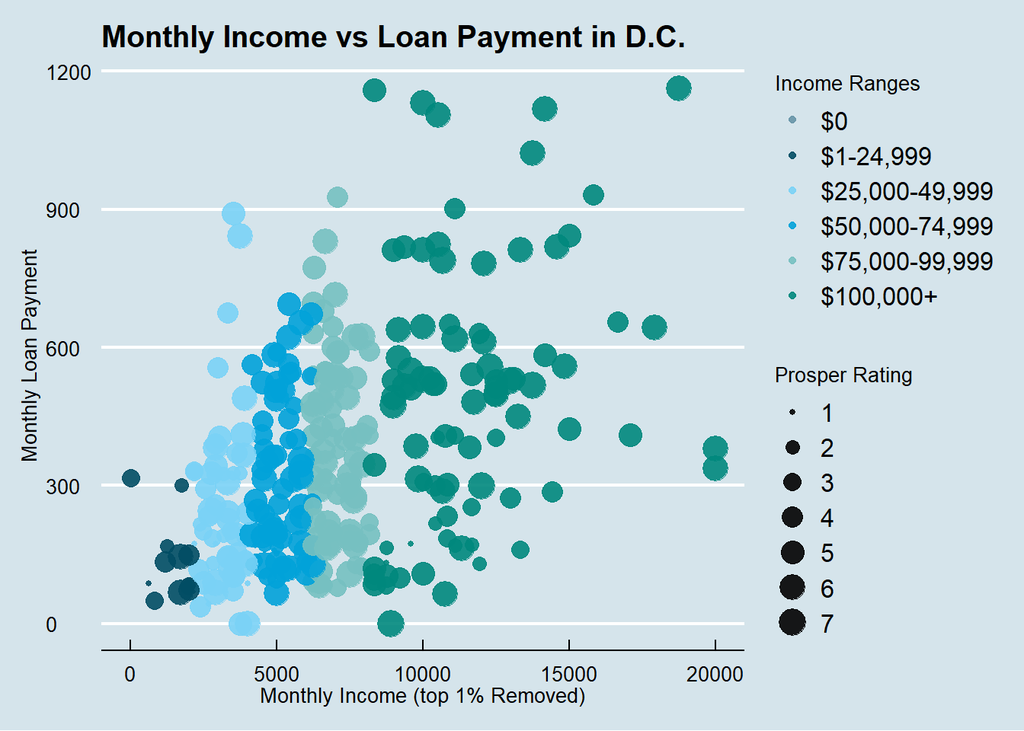

### Monthly Income vs Loan Payment in Washington, D.C.

> This graph combines two that we saw earlier buy looks at Washington, D.C. instead. It gives more information about the Prosper rating and income range vs Monthly Payments and Income. We can see the same trend of lower incomes typically being bunched closer together with the higher earners having a lot more variation in terms of the Income vs Payments. It is also not neccesarily the case the more you earn the higher your rating. After looking at income data above it was helpful for us to see this information plotted again but now looking at the Income vs Loan Payment data.

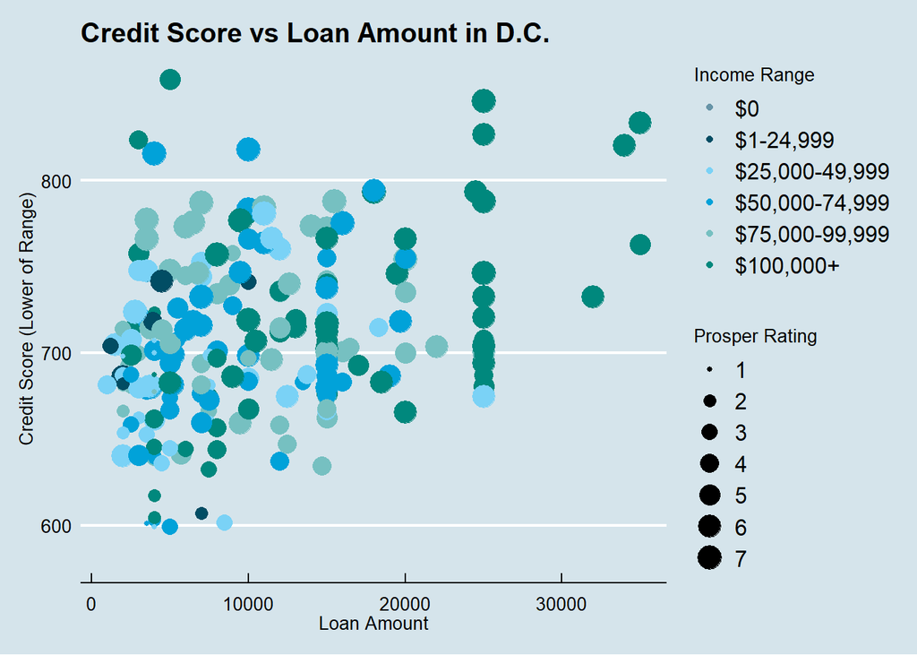

### Credit Score vs Loan Amount in Washington, D.C.

> This chart takes another look at the Income and Prosper Rating in D.C. but now we are looking at the relationship to the lower range of the Credit Rating. In the multivariate analysis we saw both of these variables along with Prosper Rating and again with Income Range in graphs, but we can use the above to see the relationship between the two. We can see from this graph that the Prosper Rating is lower for those with a lower credit score, as we would expect, but we can also see that there are those with small loan amounts and scores around 700 that also have a low rating. The reasoning behind choosing this plot was to enable us to see if the Prosper rating was liable to correlate to certain loan amounts.

# Reflection

> I think that this dataset was really interesting, and the vastness of it means that I could have explored many more areas including looking at how Occupation affects other variables. I think that I learnt a lot using many resources (detailed in ‘reference materials’) that helped me convey my points effectively. I think that one of the aspects that I found most interesting was looking at the Income Range variable and seeing how that related back to others, and how I could again relate this to real-life examples.

> I ran into difficulties when I first looked at the data, I think this is becuase it is real-life data using loans taken out all over the US (where there is a big divide from state to state) that I could not immediately see any correlations in my first sample plot. This caused me to try and plot a lot of difference variables (not all plots are included) to try and find some that I thought were relevant.

> I think I found success once I focused on a few key variables and I really tried analysing them together, I also think that looking at certain states enabled me to see clearer patterns that were not clouded by the sheer amount of data.